# 奄美大岛游客轨迹分析

Jiefeng Kang

## 引言

由于各种因素（如不同的游客、交通方式、旅行目的和停留时间的长短），基于自然的旅游行为非常复杂。移动数据为揭示游客的时空模式提供了新的机会。基于高时空分辨率的移动数据Agoop数据集，本研究通过空间聚类和空间序列分析，分析了游客的轨迹模式，并以奄美大岛为案例研究对象。

奄美大岛游客众多，尤其是夏季。岛上的基础设施在旺季面临挑战。对游客进行轨迹分析，可以探明游客的目的地轨迹、滞留时间、通勤强度、网络等等情况，基于此数据，可以对奄美大岛的旅游设施规划和管理提出建议，而且该方法同样可以应用于其他旅游城市。

本研究的主要分析流程是：基于大数据，对奄美大岛游客轨迹进行空间聚类，如此一来，按时空关系可将访客目的地分成几个cluster；对每个访客行经的cluster进行轨迹分析，可以获得访客目的地数量、顺序、滞留时间等结果；对cluster进行网络分析，可以获得研究区域交通流通网络的拓扑结构（尚未进行该分析）。

## 空间聚类

[output not shown]

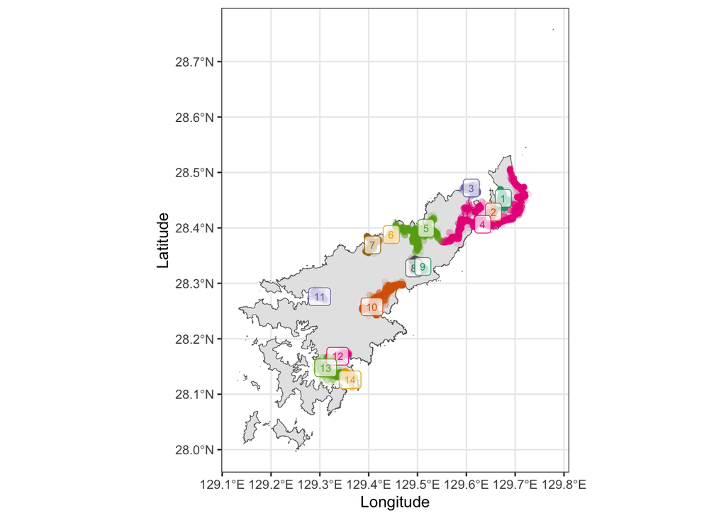

```r
ggplot() +
  geom_sf(data = amami) +
  geom_sf(
    data = gis_agoop_coord_sample %>%
      filter(cluster != 0) %>%
      group_by(cluster) %>%
      slice_sample(n = 3000),
    aes(col = cluster), alpha = 0.1
  ) +
  geom_sf_label(
    data =
      filter(gis_agoop_coord_sample, cluster != 0) %>%
      group_by(cluster) %>%
      slice_head(n = 1),
    aes(col = cluster, label = cluster), alpha = 0.7, size = 2.5
  ) +
  scale_color_manual(values = rep(brewer.pal(9, "Dark2"), 3)) +
  labs(x = "Longitude", y = "Latitude") +
  theme_bw() +
  theme(legend.position = "none")
```

## 停留时间

访客在各个聚类的停留时间如下。根据中位数或平均值来看，北部聚类的停留时间较长，其次是南部的某些聚类，然后是其他聚类。

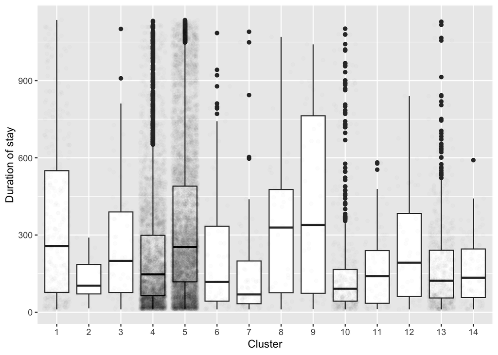

```r
# Plot duration of stay of each cluster, based on segment duration stay data.
ggplot(data = seg, aes(cluster, duration_stay)) +
  geom_boxplot() +
  geom_jitter(alpha = 0.01) +
  labs(x = "Cluster", y = "Duration of stay")
```

```r
# Table.
seg %>%
  group_by(cluster) %>%
  summarise(
    mean_dur_stay = mean(duration_stay, na.rm = TRUE),
    mid_dur_stay = median(duration_stay, na.rm = TRUE),
    sd_dur_stay = sd(duration_stay, na.rm = TRUE),
    n_dur_stay = n()
  ) %>%
  mutate(
    se_dur_stay = sd_dur_stay / sqrt(n_dur_stay),
    lower_ci =
      mean_dur_stay - qt(1 - (0.05 / 2), n_dur_stay - 1) * se_dur_stay,
    upper_ci =
      mean_dur_stay + qt(1 - (0.05 / 2), n_dur_stay - 1) * se_dur_stay
  ) %>%
  select(cluster, mid_dur_stay, mean_dur_stay, lower_ci, upper_ci, sd_dur_stay)
```

```
## # A tibble: 14 × 6
##    cluster mid_dur_stay mean_dur_stay lower_ci upper_ci sd_dur_stay
##    <fct>          <dbl>         <dbl>    <dbl>    <dbl>       <dbl>
##  1 1               257           350.    317.      383.       321.
##  2 2               103           129.     76.3     182.        87.1
##  3 3               200.          263.    211.      316.       232.
##  4 4               147           218.    212.      224.       214.
##  5 5               253           344.    337.      350.       294.
##  6 6               118           243.    184.      302.       274.
##  7 7                69           145.    108.      182.       191.
##  8 8               329           326.    239.      413.       282.
##  9 9               339           424.    329.      519.       341.
## 10 10               91           166.    146.      186.       220.
## 11 11              140           162.    130.      195.       144.
## 12 12              192.          248.    190.      307.       206.
## 13 13              122.          174.    162.      186.       169.
## 14 14              134           159.    137.      181.       119.
```

## 聚类间移动

每个游客途经的聚类数呢？下图表示访客们图景聚类数的数量，例如，第一条柱子表示在一天中途经1个聚类的访客数量。可见大部分访客在一天中都待在一个聚类中。

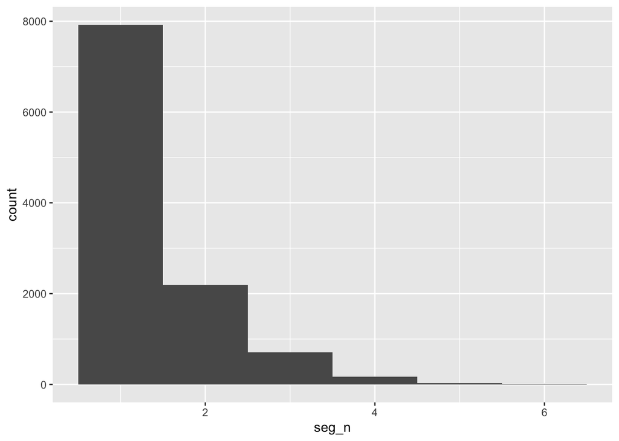

```r
seg %>%
  group_by(dailyid) %>%
  summarise(seg_n = n(), .groups = "drop") %>%
  ggplot() +
  geom_histogram(aes(seg_n), binwidth = 1)
```

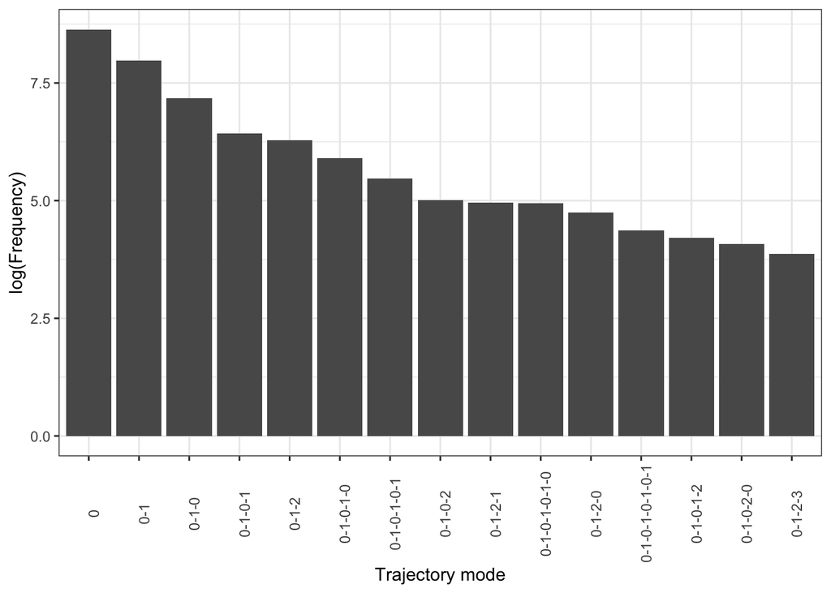

```r
ggplot(top_traj_3) +
  geom_col(aes(traj, log(freq))) +
  labs(x = "Trajectory mode", y = "log(Frequency)") +
  theme_bw() +
  theme(axis.text.x = element_text(angle = 90))
```